# Visualization

Part II

Tianyou Wang

2022-10-11

```r
library(tidyverse)
library(patchwork)
```

## Load the Weather Data

```r
weather_df =
  rnoaa::meteo_pull_monitors(
    c("USW00094728", "USC00519397", "USS0023B17S"),
    var = c("PRCP", "TMIN", "TMAX"),
    date_min = "2017-01-01",
    date_max = "2017-12-31") %>%
  mutate(
    name = recode(
      id,
      USW00094728 = "CentralPark_NY",
      USC00519397 = "Waikiki_HA",
      USS0023B17S = "Waterhole_WA"),
    tmin = tmin / 10,
    tmax = tmax / 10) %>%
  select(name, id, everything())
```

[output not shown]

[output not shown]

[output not shown]

[output not shown]

[output not shown]

[output not shown]

[output not shown]

[output not shown]

[output not shown]

```r
weather_df
```

```
## # A tibble: 1,095 × 6
##    name           id          date        prcp  tmax  tmin
##    <chr>          <chr>       <date>     <dbl> <dbl> <dbl>
##  1 CentralPark_NY USW00094728 2017-01-01     0   8.9   4.4
##  2 CentralPark_NY USW00094728 2017-01-02    53   5     2.8
##  3 CentralPark_NY USW00094728 2017-01-03   147   6.1   3.9
##  4 CentralPark_NY USW00094728 2017-01-04     0  11.1   1.1
##  5 CentralPark_NY USW00094728 2017-01-05     0   1.1  -2.7
##  6 CentralPark_NY USW00094728 2017-01-06    13   0.6  -3.8
##  7 CentralPark_NY USW00094728 2017-01-07    81  -3.2  -6.6
##  8 CentralPark_NY USW00094728 2017-01-08     0  -3.8  -8.8
##  9 CentralPark_NY USW00094728 2017-01-09     0  -4.9  -9.9
## 10 CentralPark_NY USW00094728 2017-01-10     0   7.8  -6
## # … with 1,085 more rows
```

## *Labels*

Providing informative axis labels, plot titles, and captions, via `labs(title = "", x = "", y = "", caption = "")`.

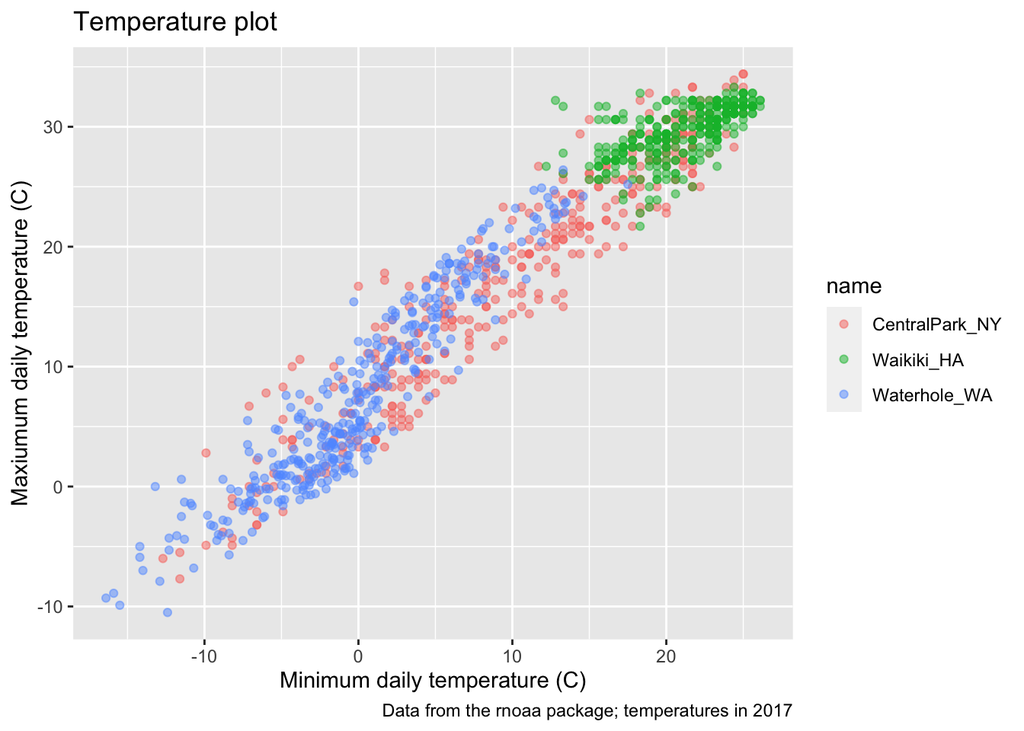

```r
weather_df %>%
  ggplot(aes(x = tmin, y = tmax)) +
  geom_point(aes(color = name), alpha = .5) +
  labs(
    title = "Temperature plot",
    x = "Minimum daily temperature (C)",
    y = "Maxiumum daily temperature (C)",
    caption = "Data from the rnoaa package; temperatures in 2017"
  )
```

## *Scales*

We can set scales for x and y axis by using `scale_x_continuous()`. We can also label them by using `labels = c()` inside of `scale_x_continuous()`.

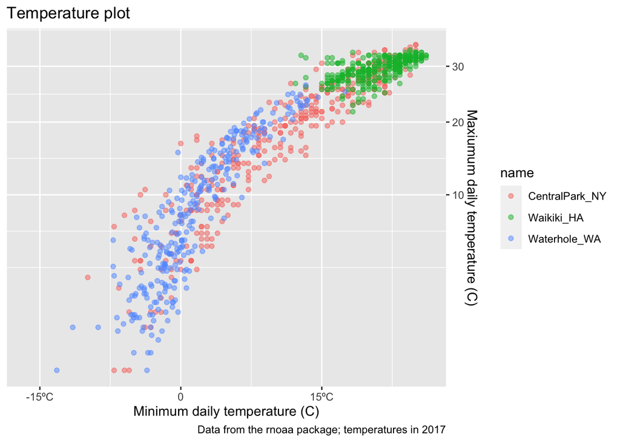

```r
weather_df %>%
  ggplot(aes(x = tmin, y = tmax)) +
  geom_point(aes(color = name), alpha = .5) +
  labs(
    title = "Temperature plot",
    x = "Minimum daily temperature (C)",
    y = "Maxiumum daily temperature (C)",
    caption = "Data from the rnoaa package; temperatures in 2017") +
  scale_x_continuous(
    breaks = c(-15, 0, 15),
    labels = c("-15ºC", "0", "15ºC")) +
  scale_y_continuous(
    trans = "sqrt",
    position = "right"
  )
```

What we did for the x, y-axis scales:

- `breaks = c()` setting the scale points, seperated by commas
- `labels = c()` choice how we label the scale points, such as adding units
- `trans = ""` is used to transform the data, such as trans = “sqrt” (square root) and trans = “log”
- `position = "right"` putting the scale discription on the right side of graph

### Color Scales

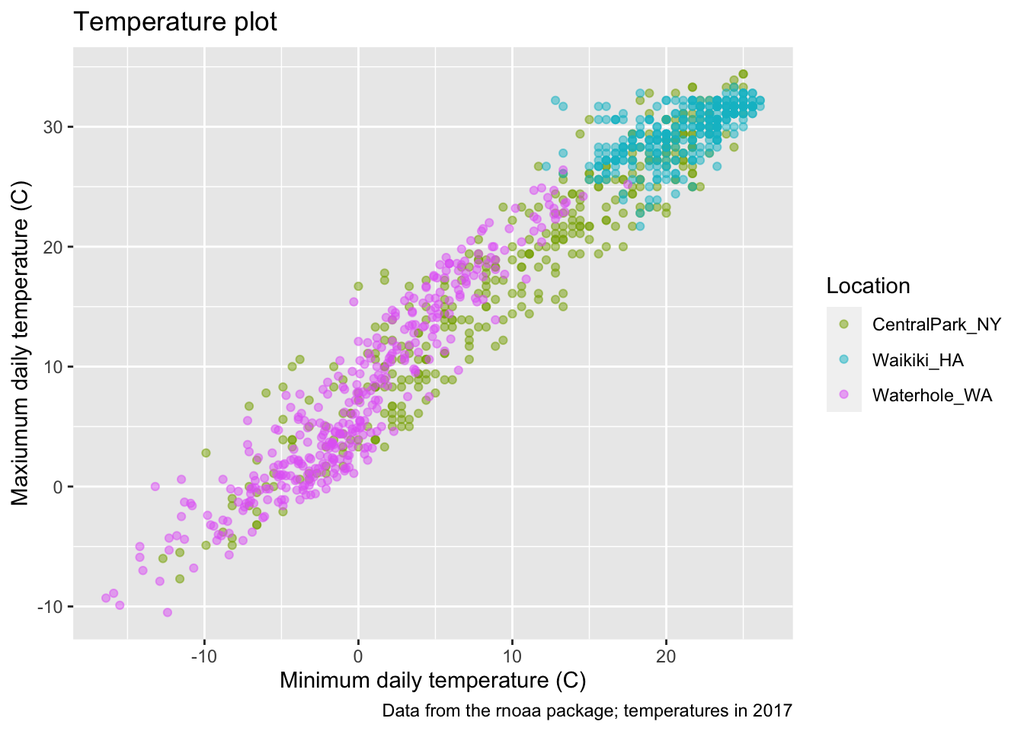

```r
weather_df %>%
  ggplot(aes(x = tmin, y = tmax)) +
  geom_point(aes(color = name), alpha = .5) +
  labs(
    title = "Temperature plot",
    x = "Minimum daily temperature (C)",
    y = "Maxiumum daily temperature (C)",
    caption = "Data from the rnoaa package; temperatures in 2017") +
  scale_color_hue(
    name = "Location",
    h = c(100, 300))
```

Using `name = "xxx"` to rename the coloring variance, in this case we use (name = “Location”) to change our variable “name” to “Location”. Note: the variable “name” accidentally shared the same name with the (name = “xxx”) command.

The default hue is “h = c(1, 360)”

### Viridis Package for Color Scheme

Trying to create your own color scheme usually doesn’t go well. You can use the “viridis package” instead. There are several options, but the default color scheme works nicely!

Note: `viridis::scale_color_viridis()` assume the variable you put in is a continuous variable. If we are applying it to a discrete variable (this case, location,) we want to write `discrete = TRUE` inside the scale_color_viridis command.

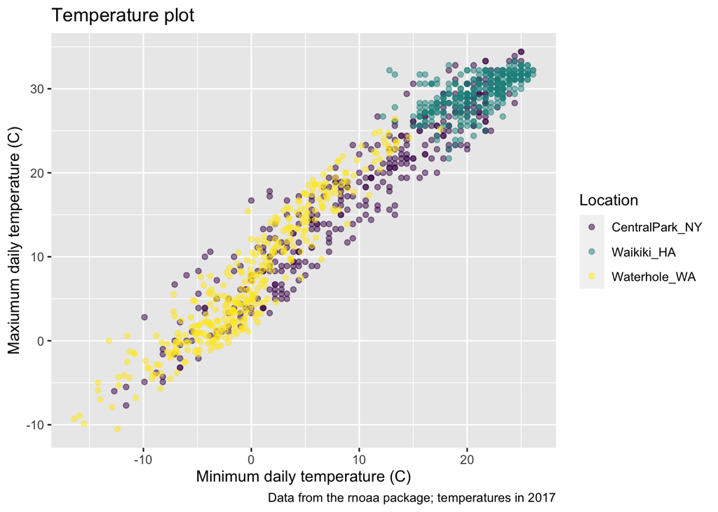

```r
weather_df %>%
  ggplot(aes(x = tmin, y = tmax)) +
  geom_point(aes(color = name), alpha = .5) +
  labs(
    title = "Temperature plot",
    x = "Minimum daily temperature (C)",
    y = "Maxiumum daily temperature (C)",
    caption = "Data from the rnoaa package; temperatures in 2017") +
  viridis::scale_color_viridis(
    name = "Location",
    discrete = TRUE)
```